# 205.1. The Point Spread Function for Visit Images

For the Rubin Science Platform at data.lsst.cloud.  
Data Release: [Data Preview 1](https://dp1.lsst.io)  
Container Size: large  
LSST Science Pipelines version: r29.2.0  
Last verified to run: 2025-09-17  
Repository: github.com/lsst/tutorial-notebooks

**Learning objective:** To understand the format and metadata of the Point Spread Function in a visit image.

**LSST data products:** `source`, `visit_image`

**Packages:** `lsst.daf.butler`, `lsst.afw.display`, `lsst.rsp`, `lsst.geom`, `lsst.rsp.get_tap_service`, `astropy`, `numpy`, `matplotlib`, `scipy`.

**Credit:** Originally developed by Andrés A. Plazas Malagón and the Rubin Community Science team. Section 7 on "PSF model residuals" is based on a notebook by Pierre-François Léget. Please consider acknowledging them if this notebook is used for the preparation of journal articles, software releases, or other notebooks.

**Get Support:** Everyone is encouraged to ask questions or raise issues in the [Support Category](https://community.lsst.org/c/support) of the Rubin Community Forum. Rubin staff will respond to all questions posted there.

## 1. Introduction

This notebook demonstrates how to visualize the PSF model of a `visit_image` at a particular location, as well as how to explore the PSF model methods to calculate and visualize its properties. The final section shows an example of PSF model residual visualization.

A `visit_image` is a fully processed, science-ready astronomical image from a single detector, sometimes also referred to as a Processed Visit Image (`pvi`). A `visit_image` object includes attributes such as a World Coordinate System (WCS) astrometric solution and an associated Point Spread Function (PSF) model.

For LSSTComCam, the PSF modeling was performed using the ["PSF in the Full Field of View"](https://ui.adsabs.harvard.edu/abs/2021ascl.soft02024J/abstract) (PIFF) software, with a `PixelGrid` model and `BasisPolynomial` interpolation on a per-CCD (Charge-Coupled Device) basis, in either pixel or sky coordinates. Currently, the model does not include features such as tree ring distortions or chromatic PSF corrections, which are planned for future implementation.

**Related tutorials:** DP1 tutorial on `visit_image`s and PSF in coadded images.

### 1.1. Import packages

Import `numpy`, a fundamental package for scientific computing with arrays in Python (numpy.org), and matplotlib, a comprehensive library for data visualization ([matplotlib.org](https://matplotlib.org/); [matplotlib gallery](https://matplotlib.org/stable/gallery/index.html)).

From `scipy`, import tools for numerical optimization and statistics, including curve fitting and computation of distribution skewness ([scipy.org](https://scipy.org/); [scipy docs](https://docs.scipy.org/doc/scipy/reference/)).

From the LSST Science Pipelines, import modules for display utilities, geometry handling, and the Butler data access system ([pipelines.lsst.io](https://pipelines.lsst.io/)).

From `lsst.rsp`, import functions to interact with the Rubin Science Platform’s TAP (Table Access Protocol) service ([rsp.lsst.io](https://rsp.lsst.io/); [dm.lsst.org](https://dm.lsst.org/)).

```python
import matplotlib.pyplot as plt
import numpy as np
from scipy.optimize import curve_fit
from scipy.stats import skew

import lsst.afw.display as afwDisplay
import lsst.geom
from lsst.daf.butler import Butler
from lsst.rsp import get_tap_service
```

### 1.2. Define parameters and functions

**Constant**: `SIGMA_TO_FWHM`

Defines the convertion factor between the standard deviation `sigma` of a Gaussian function a the full-withd at half-maximum (FWHM): $2\sqrt{2\ln(2)}$

```python
SIGMA_TO_FWHM = 2.0*np.sqrt(2.0*np.log(2.0))
```

**Function**: `gauss`

Defines a one-dimensional Gaussian profile.

```python
def gauss(x, a, x0, sigma):
    """Evaluate a 1D Gaussian function.

    Parameters
    ----------
    x : `array_like`
        Input values where the Gaussian is evaluated.
    a : `float`
        Amplitude of the Gaussian peak.
    x0 : `float`
        Mean (center) of the Gaussian.
    sigma : `float`
        Standard deviation (width) of the Gaussian.

    Returns
    -------
    y : `array_like`
        Values of the Gaussian function evaluated at `x`.
    """
    return a * np.exp(-(x - x0)**2 / (2 * sigma**2))
```

Set `afwDisplay` to use `matplotlib` for image display.

```python
afwDisplay.setDefaultBackend('matplotlib')
```

Create an instance of the Table Access Protocol (TAP) service, and assert that it exists.

```python
rsp_tap = get_tap_service("tap")
assert rsp_tap is not None
```

Instantiate the Butler with the appropiate DP1 repository and collection.

```python
butler = Butler('dp1', collections='LSSTComCam/DP1')
assert butler is not None
```

## 2. Visualize the PSF model

For a given visit ID and a given ComCam detector, get the `visit_image` via the Butler.

First, retrieve a visit reference object around a chosen coordinate on the sky. Use the center location (International Celestial Reference System coordinates in degrees) of one of the fields observed by LSSTComCam during commissioning, the Extended Chandra Deep South Field.

```python
ra, dec = 53.13, -28.10
my_band = 'i'
```

```python
visitimage_refs = butler.query_datasets('visit_image',
                                        where="visit.region OVERLAPS POINT(ra, dec) "
                                        f"and band='{my_band}'",
                                        bind={'ra': ra, 'dec': dec},
                                        order_by=['visit', 'detector'],
                                        with_dimension_records=True,
                                        limit=1)
```

```python
visitimage_refs
```

```
[DatasetRef(DatasetType('visit_image', {band, instrument, day_obs, detector, physical_filter, visit}, ExposureF), {instrument: 'LSSTComCam', detector: 0, visit: 2024110800245, band: 'i', day_obs: 20241108, physical_filter: 'i_06'}, run='LSSTComCam/runs/DRP/DP1/DM-51335', id=1e1cd322-4ddd-4918-b2ac-c…
```

Retrieve the `visit_image` object from the reference.

```python
visit_image = butler.get(visitimage_refs[0])
```

Get the PSF model associated to the `visit_image`.

```python
psf = visit_image.getPsf()
```

Define a central point where the PSF model should be evaluated.

```python
xy = lsst.geom.Point2D(300, 300)
```

Use the `computeImage()` method to display the PSF model centered around the chosen point.

```python
psf_image = psf.computeImage(xy)
```

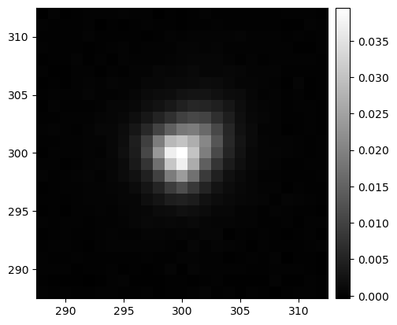

```python
afw_display = afwDisplay.Display(frame=1)
afw_display.mtv(psf_image.convertF())
```

> **Figure 1:** PSF image using the `computeImage()` method.

Use the `computeKernelImage()` method. Note that with this method the postage stamp's coordinates are centered at the origin of the image. The coordinates of this origin point are (0, 0), resulting in negative coordinates for the lower left point.

```python
psf_image_kernel = psf.computeKernelImage(xy)
```

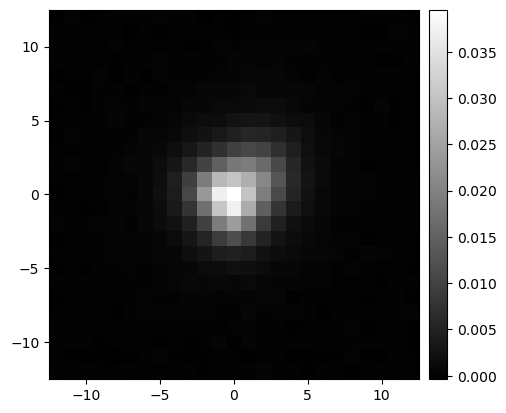

```python
afw_display = afwDisplay.Display(frame=1)
afw_display.mtv(psf_image_kernel.convertF())
```

> **Figure 2:** PSF image using the `computeKernelImage()` method.

## 3. PSF model methods and properties

**Option:** explore the methods available for `psf`

```python
# psf.
```

### 3.1. PSF size

Obtain the size of the PSF, as a $\sigma$ and full-width at half maximum (FWHM).

```python
psf_shape = psf.computeShape(xy)
```

```python
psf_sigma = psf_shape.getDeterminantRadius()
psf_fwhm = psf_sigma * SIGMA_TO_FWHM
print(f"PSF size: {psf_sigma: .3f} pix.\nPSF FWHM {psf_fwhm: .3f} pix.")
```

```
PSF size:  1.939 pix.
PSF FWHM  4.566 pix.
```

### 3.2. Second moments

Display the PSF second moments.

```python
print(f"PSF Ixx: {psf_shape.getIxx(): .3f} pix^2")
print(f"PSF Iyy: {psf_shape.getIyy(): .3f} pix^2")
print(f"PSF Ixy: {psf_shape.getIxy(): .3f} pix^2")
```

```
PSF Ixx:  3.836 pix^2
PSF Iyy:  3.753 pix^2
PSF Ixy:  0.505 pix^2
```

### 3.3. Aperture flux

Display the PSF flux from aperture photometry weighted by a sinc function within 1, 2, and 3$\sigma$. Recall that the total flux of the PSF kernel has been normalized to an integrated flux of 1.

```python
psf_apflux_1s = psf.computeApertureFlux(radius=1.0*psf_sigma, position=xy)
psf_apflux_2s = psf.computeApertureFlux(radius=2.0*psf_sigma, position=xy)
psf_apflux_3s = psf.computeApertureFlux(radius=3.0*psf_sigma, position=xy)
```

```python
print("PSF aperture fluxes: ")
print(f"  within 1σ: {psf_apflux_1s: .3f}")
print(f"  within 2σ: {psf_apflux_2s: .3f}")
print(f"  within 3σ: {psf_apflux_3s: .3f}")
```

```
PSF aperture fluxes:
  within 1σ:  0.348
  within 2σ:  0.738
  within 3σ:  0.894
```

### 3.4. Peak flux

Print the peak flux of the PSF kernel.

```python
psf_peak = psf.computePeak(position=xy)
```

```python
print(f"PSF peak value at center: {psf_peak: .3f}")
```

```
PSF peak value at center:  0.040
```

### 3.5. Postage stamp dimensions

Calculate the PSF postage stamp dimensions, in pixels.

```python
psf_dims = psf.computeImage(xy).getDimensions()
```

```python
print(f"PSF postage stamp dimensions: {psf_dims} pix ")
```

```
PSF postage stamp dimensions: (25, 25) pix
```

## 4. PSF radial profile

Extract the data array from the PSF image, and compute its center from the PSF dimensions.

```python
psf_image_array = psf_image.array
xlen, ylen = psf_dims
center = np.array([xlen / 2, ylen / 2])
```

```python
print(f"PSF center position: ({center[0]: .1f}, {center[1]: .1f}) pix")
```

```
PSF center position: ( 12.5,  12.5) pix
```

Create a coordinate grid and calculate the distances from all the pixels to the center.

```python
y, x = np.indices((xlen, ylen))
coords = np.stack((x, y), axis=-1)
distances = np.linalg.norm(coords - center, axis=-1)
```

Apply a radial mask.

```python
mask = (distances <= xlen / 2)
values = psf_image_array[mask]
dists = distances[mask]
```

Set initial parameters and bounds for a Gaussian fit of the PSF radial profile.

```python
p0 = [np.max(values), 0, 10]
bounds = ((0, 0, 0), (np.inf, np.inf, np.inf))
```

Fit a Gaussian profile.

```python
try:
    pars, _ = curve_fit(gauss, dists, values, p0=p0, bounds=bounds)
    pars[0] = np.abs(pars[0])
    pars[2] = np.abs(pars[2])
except RuntimeError:
    pars = None
```

Plot the radial profile.

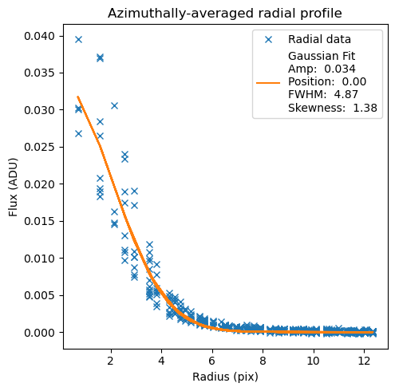

```python
fig, ax = plt.subplots(figsize=(6, 5))
ax.plot(dists, values, 'x', label='Radial data')

if pars is not None:
    fitAmp, fitMean, fitSigma = pars
    fitFwhm = fitSigma * SIGMA_TO_FWHM

    x_fit = np.linspace(-np.max(dists), np.max(dists), 200)
    y_fit = gauss(x_fit, *pars)
    fitline = gauss(dists, *pars)
    skewness_val = skew(y_fit)

    ax.plot(dists, fitline, label=(
        f"Gaussian Fit\n"
        f"Amp: {fitAmp: .3f}\n"
        f"Position: {fitMean: .2f}\n"
        f"FWHM: {fitFwhm: .2f}\n"
        f"Skewness: {skewness_val: .2f}"
    ))

ax.set_xlabel("Radius (pix)")
ax.set_ylabel("Flux (ADU)")
ax.set_title("Azimuthally-averaged radial profile")
ax.set_aspect(1.0 / ax.get_data_ratio(), adjustable='box')
ax.legend()
plt.tight_layout()
plt.show()
```

> **Figure 3:** Azimuthally-averaged PSF radial profile, fitted with a Gaussian function.

## 5. PSF curve of growth

Sort the distances calculated above.

```python
sorted_indices = np.argsort(dists)
dists_sorted = dists[sorted_indices]
values_sorted = values[sorted_indices]
```

Compute the normalized cumulative flux.

```python
cum_fluxes = np.cumsum(values_sorted)
cum_fluxes_norm = cum_fluxes / np.max(cum_fluxes)
```

Plot the PSF curve of growth.

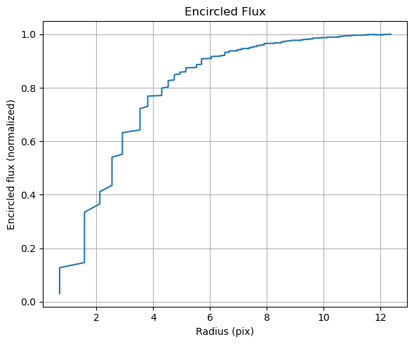

```python
fig, ax = plt.subplots(figsize=(6, 5))
ax.plot(dists_sorted, cum_fluxes_norm, markersize=10)

ax.set_ylabel('Encircled flux (normalized)')
ax.set_xlabel('Radius (pix)')
ax.set_title("Encircled Flux")
ax.grid(True)

plt.tight_layout()
plt.show()
```

> **Figure 4:** PSF curve of growth.

## 6. Make a 2D PSF contour plot

Define intensity percentiles for the contour plots.

```python
vmin = np.percentile(psf_image_array, 0.1)
vmax = np.percentile(psf_image_array, 99.9)
nContours = 10
lvls = np.linspace(vmin, vmax, nContours)
```

Define a coordinate grid centered around (0, 0).

```python
xx, yy = np.meshgrid(np.linspace(-xlen / 2, xlen / 2, xlen),
                     np.linspace(-ylen / 2, ylen / 2, ylen))
```

Plot the contours.

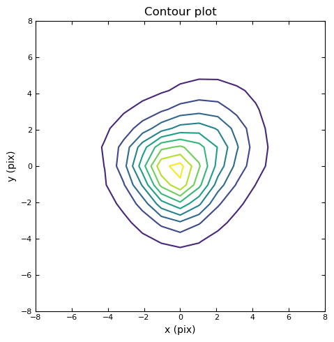

```python
fig, ax = plt.subplots(figsize=(6, 5))
ax.contour(xx, yy, psf_image_array, levels=lvls)
ax.tick_params(which="both", direction="in", top=True, right=True, labelsize=8)
ax.set_aspect("equal")
ax.set_xlabel('x (pix)')
ax.set_ylabel('y (pix)')
ax.set_title("Contour plot")
ax.set_xlim([-8, 8])
ax.set_ylim([-8, 8])
plt.tight_layout()
plt.show()
```

> **Figure 5:** PSF countour plot.

## 7. PSF model residuals

Find a list of stars used for PSF modeling in the `source` catalog by setting the `calib_psf_used` flag to `True`, for the `visit_id` and `detector_id` defined before. For one star, display the residuals between the `Piff` PSF model at the star location and the observed star, using the `visit_image` object.

Get a table of stars used for PSF modeling by querying the `source` table with the TAP service.

```python
visit_id = visitimage_refs[0].dataId['visit']
detector_id = visitimage_refs[0].dataId['detector']
```

```python
query = (
    "SELECT sourceId, x, y, "
    "coord_ra, coord_dec, "
    "psfFlux, "
    "calib_psf_used "
    "FROM dp1.Source "
    f"WHERE visit = {visit_id} "
    f"AND detector = {detector_id} "
    "AND calib_psf_used = 1"
)
```

```python
job = rsp_tap.submit_job(query)
job.run()
job.wait(phases=['COMPLETED', 'ERROR'])
print('Job phase is', job.phase)
if job.phase == 'ERROR':
    job.raise_if_error()
assert job.phase == 'COMPLETED'
psf_used_table = job.fetch_result().to_table()
```

```
Job phase is COMPLETED
```

```python
print(len(psf_used_table))
```

```
76
```

```python
psf_used_table.sort('sourceId')
```

Choose the second star in the sorted results.

```python
x_star, y_star = psf_used_table['x'][1], psf_used_table['y'][1]
```

```python
print(f"Star position: ({x_star: .1f}, {y_star: .1f}) pix")
```

```
Star position: ( 1947.8,  208.3) pix
```

Use the `visit_image` for the `visit_id` and `detector_id` obtained previously.

Get a postage stamp image of the star around its location, using as size the PSF model dimensions calculated previously.

```python
position_star = lsst.geom.Point2D(x_star, y_star)
star_cutout = visit_image.getCutout(position_star, lsst.geom.Extent2I(xlen, ylen))
```

Get the observed star image.

```python
star_masked_image = star_cutout.getMaskedImage()
star_image_array = star_masked_image.image.array / np.sum(star_masked_image.image.array)
```

Get the PSF model image.

```python
psf_model = psf.computeImage(position_star)
psf_array = psf_model.array
```

Plot the observed star, the Piff model at that location, and the residuals.

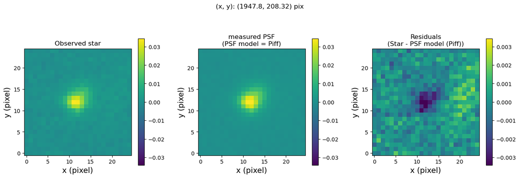

```python
max_star_image_array = np.max(np.abs(star_image_array))
PSF_model_name = "Piff"

fig, axes = plt.subplots(1, 3, figsize=(14, 5))
fig.subplots_adjust(wspace=0.3, left=0.07, right=0.95, bottom=0.15, top=0.8)
fig.suptitle(f"(x, y): {position_star} pix", fontsize=12)

images = [
    (star_image_array, 'Observed star', max_star_image_array),
    (
        psf_array,
        f"measured PSF\n(PSF model = {PSF_model_name})",
        max_star_image_array
    ),
    (
        star_image_array - psf_array,
        f"Residuals\n(Star - PSF model ({PSF_model_name}))",
        max_star_image_array / 10
    )
]

for ax, (img, title, v) in zip(axes, images):
    im = ax.imshow(img, vmin=-v, vmax=v, cmap='viridis', origin='lower')
    fig.colorbar(im, ax=ax)
    ax.set_xlabel('x (pixel)', fontsize=14)
    ax.set_ylabel('y (pixel)', fontsize=14)
    ax.set_title(title, fontsize=12)
```

> **Figure 6:** Measured star used for PSF modeling (left), PSF model from Piff (center), and residuals (right).